# 🚀 Project 99 — Space Missions Analysis

## Launches by Country

The country can be extracted from the **Location column**.

```python
df["Country"] = df["Location"].str.split(",").str[-1].str.strip()
country_launches = df["Country"].value_counts()

country_launches.head(10)
```

```
Country
Russia           1395
USA              1344
Kazakhstan        701
France            303
China             268
Japan             126
India              76
Pacific Ocean      36
New Zealand        13
Iran               13
Name: count, dtype: int64
```

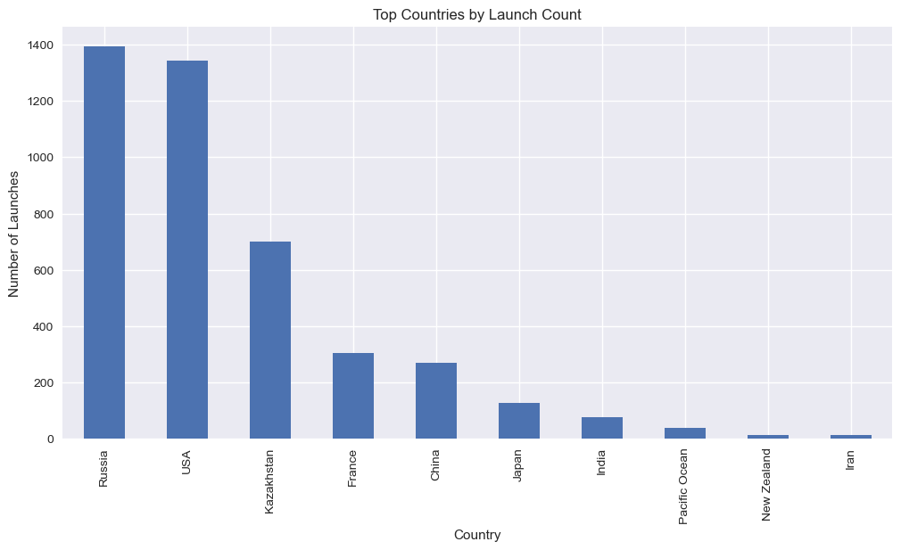

```python
plt.figure(figsize=(12,6))

country_launches.head(10).plot(kind="bar")

plt.title("Top Countries by Launch Count")
plt.xlabel("Country")
plt.ylabel("Number of Launches")

plt.show()
```

## Mission Success Rate

We want to evaluate how safe space missions have been.

```python
mission_status = df["Mission_Status"].value_counts()

mission_status
```

```
Mission_Status
Success              3879
Failure               339
Partial Failure       102
Prelaunch Failure       4
Name: count, dtype: int64
```

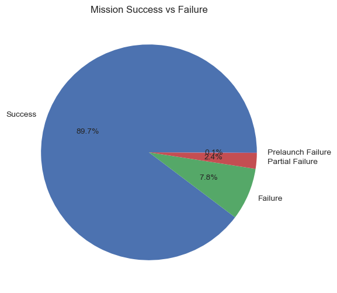

```python
plt.figure(figsize=(6,6))

plt.pie(
    mission_status,
    labels=mission_status.index,
    autopct="%1.1f%%"
)

plt.title("Mission Success vs Failure")

plt.show()
```

## Mission Safety Over Time

```python
success_rate = df.groupby("Year")["Mission_Status"].apply(
    lambda x: (x == "Success").mean()
)
```

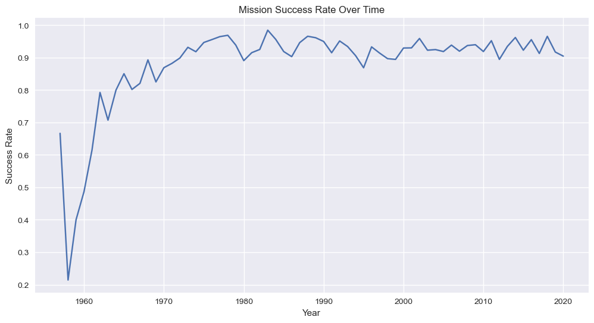

```python
plt.figure(figsize=(12,6))

plt.plot(success_rate)

plt.title("Mission Success Rate Over Time")
plt.xlabel("Year")
plt.ylabel("Success Rate")

plt.show()
```

## Mission Costs

How has the cost of space missions changed over time?

```python
price_per_year = df.groupby("Year")["Price"].mean()
```

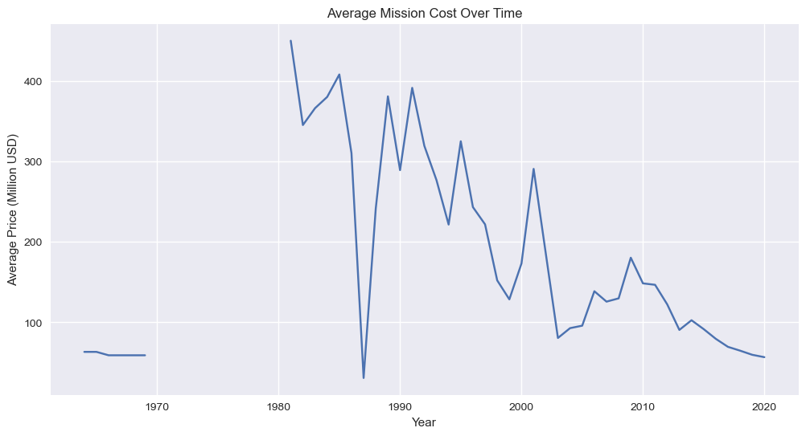

```python
plt.figure(figsize=(12,6))

plt.plot(price_per_year)

plt.title("Average Mission Cost Over Time")
plt.xlabel("Year")
plt.ylabel("Average Price (Million USD)")

plt.show()
```

## Launch Frequency by Month

```python
launch_months = df["Month"].value_counts().sort_index()
```

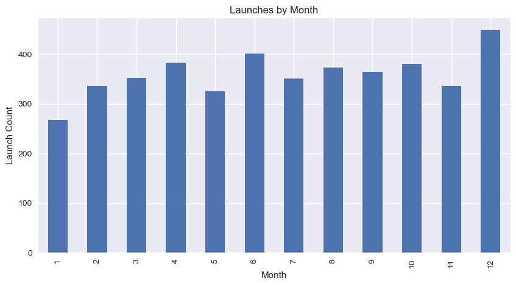

```python
plt.figure(figsize=(10,5))

launch_months.plot(kind="bar")

plt.title("Launches by Month")
plt.xlabel("Month")
plt.ylabel("Launch Count")

plt.show()
```

## Interactive Launch Timeline

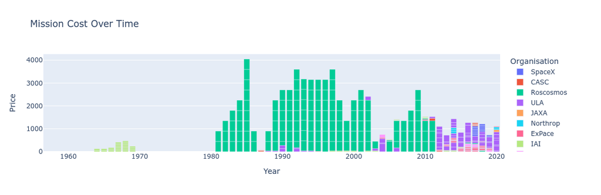

```python
fig = px.bar(
    df,
    x="Year",
    y="Price",
    color="Organisation",
    title="Mission Cost Over Time",
)

fig.show()
```

## Key Insights

### 1. Space race dominance

Early launches were dominated by **USA and USSR**.

### 2. Rise of private companies

Companies like **SpaceX** are responsible for the modern increase in launch frequency.

### 3. Mission success rate

Space missions have become **significantly safer over time**.

### 4. Costs

Mission costs vary widely depending on rocket type and organisation.

### 5. Launch timing

Certain months see slightly higher launch frequencies, likely due to **weather and orbital conditions**.

## Conclusion

This project demonstrates how Python can be used to:

- Clean real-world datasets
- Perform exploratory data analysis
- Visualise trends
- Extract meaningful insights

Tools used:

- Python
- Pandas
- Matplotlib
- Seaborn
- Plotly

This notebook is part of my **100 Python Projects Challenge**.